# TidyVerse Create

James Chun

October 25, 2025

## Introduction

Here I will be working with two Kaggle datasets sourced from https://www.kaggle.com/datasets/sidtwr/videogames-sales-dataset/data  
The two datasets contains information for the highest video game sales from the 2010’s for the PS4 and Xbox One. The data also contains the publisher, genre, date released, and the sales for various counts (in units per million).

## Load Libraries

```r
library(tidyverse)
library(ggplot2)
library(RCurl)
```

## Import Data

Data will be stored in an external github and accessed virtually. Note again that the units for the sales per country are in millions of copies sold.

```r
PS4_sales <- getURL("https://media.githubusercontent.com/media/Ryungje/DATA607/refs/heads/main/TidyVerse%20Create%20Project/PS4_GamesSales.csv") %>%
  read.csv(text = .)

XboxOne_sales <- getURL("https://media.githubusercontent.com/media/Ryungje/DATA607/refs/heads/main/TidyVerse%20Create%20Project/XboxOne_GameSales.csv") %>%
  read.csv(text = .)
```

## Data Tidying

```r
PS4_sales <- PS4_sales %>%
  mutate(North.America = North.America * 1000000,
         Europe = Europe * 1000000,
         Japan = Japan * 1000000,
         Rest.of.World = Rest.of.World * 1000000,
         Global = Global * 1000000)


XboxOne_sales <- XboxOne_sales %>%
  mutate(North.America = North.America * 1000000,
         Europe = Europe * 1000000,
         Japan = Japan * 1000000,
         Rest.of.World = Rest.of.World * 1000000,
         Global = Global * 1000000)
```

## Exploratory Data Analysis

First, sort the datasets for highest sales globally and observe the head.

```r
XboxOne_sales %>%
  arrange(desc(Global)) %>%
  head()
```

```
##   Pos                           Game Year            Genre         Publisher
## 1   1             Grand Theft Auto V 2014           Action    Rockstar Games
## 2   2      Call of Duty: Black Ops 3 2015          Shooter        Activision
## 3   3             Call of Duty: WWII 2017          Shooter        Activision
## 4   4          Red Dead Redemption 2 2018 Action-Adventure    Rockstar Games
## 5   5                      MineCraft 2014             Misc Microsoft Studios
## 6   6 Call of Duty: Advanced Warfare 2014          Shooter        Activision
##   North.America  Europe Japan Rest.of.World  Global
## 1       4700000 3250000 10000        760000 8720000
## 2       4630000 2040000 20000        680000 7370000
## 3       3750000 1910000     0        570000 6230000
## 4       3760000 1470000     0        540000 5770000
## 5       3230000 1710000     0        490000 5430000
## 6       3250000 1490000 10000        480000 5220000
```

From this we can see that for the Xbox One, GTA V holds the highest global sales, followed by CoD Black Ops 3, CoD WWII and Red Dead Redemption 2.

```r
PS4_sales %>%
  arrange(desc(Global)) %>%
  head()
```

```
##                        Game Year            Genre       Publisher North.America
## 1        Grand Theft Auto V 2014           Action  Rockstar Games       6060000
## 2 Call of Duty: Black Ops 3 2015          Shooter      Activision       6180000
## 3     Red Dead Redemption 2 2018 Action-Adventure  Rockstar Games       5260000
## 4        Call of Duty: WWII 2017          Shooter      Activision       4670000
## 5                   FIFA 18 2017           Sports       EA Sports       1270000
## 6                   FIFA 17 2016           Sports Electronic Arts       1260000
##    Europe  Japan Rest.of.World   Global
## 1 9710000 600000       3020000 19390000
## 2 6050000 410000       2440000 15090000
## 3 6210000 210000       2260000 13940000
## 4 6210000 400000       2120000 13400000
## 5 8640000 150000       1730000 11800000
## 6 7950000 120000       1610000 10940000
```

Meanwhile, for the PS4, the same is mostly true except Red Dead Redemption 2 takes the third spot from CoD WWII.

### Graphs

Simple visuals created using graphing functions from ggplot2.

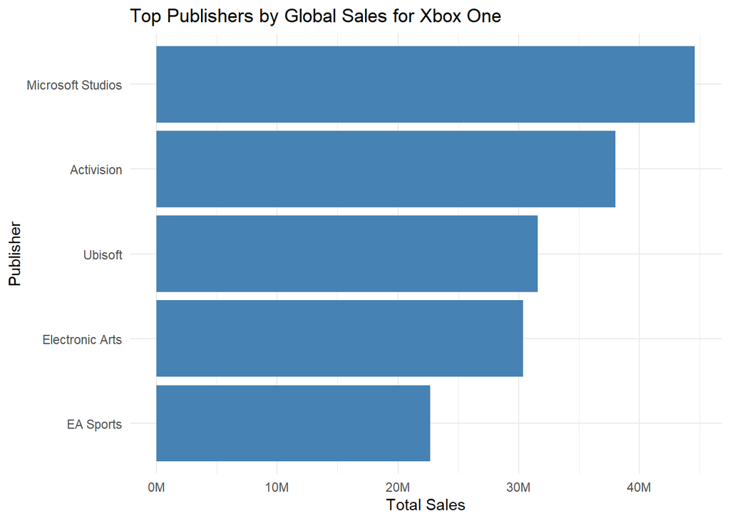

```r
XboxOne_sales %>%
  # Count top 5 sales by publisher
  group_by(Publisher) %>%
  summarise(total_sales = sum(Global, na.rm = TRUE)) %>%
  arrange(desc(total_sales)) %>%
  head(5) %>%

  # Make plot
  ggplot(aes(x = reorder(Publisher, total_sales), y = total_sales)) +
  geom_bar(stat = "identity", fill = "steelblue") +
  coord_flip() +

  # Customize plot
  labs(
    title = "Top Publishers by Global Sales for Xbox One",
    x = "Publisher",
    y = "Total Sales"
  ) +
  scale_y_continuous(labels = function(x) paste0(x / 1e6, "M")) +
  theme_minimal()
```

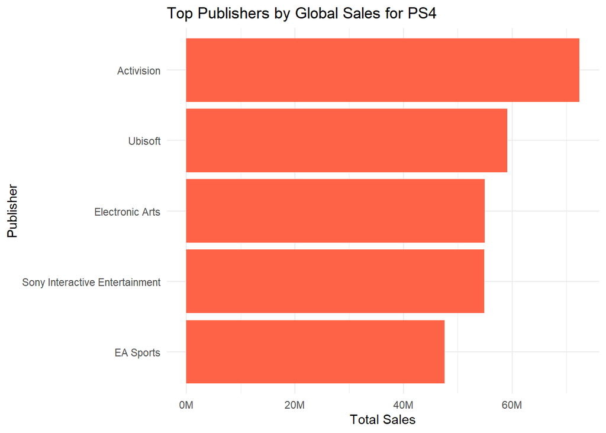

```r
PS4_sales %>%
  # Count top 5 sales by publisher
  group_by(Publisher) %>%
  summarise(total_sales = sum(Global, na.rm = TRUE)) %>%
  arrange(desc(total_sales)) %>%
  head(5) %>%

  # Make plot
  ggplot(aes(x = reorder(Publisher, total_sales), y = total_sales)) +
  geom_bar(stat = "identity", fill = "tomato") +
  coord_flip() +

  # Customize plot
  labs(
    title = "Top Publishers by Global Sales for PS4",
    x = "Publisher",
    y = "Total Sales"
  ) +
  scale_y_continuous(labels = function(x) paste0(x / 1e6, "M")) +
  theme_minimal()
```

Again, the data for the two consoles appear to be similar. However, Sony Interactive makes a notable contribution to global sales for the PS4 console. This is interesting and could be the result of Sony exclusives on the PS4: another motivation for people to buy the PS4.

## Summary

In this vignette, we explored some basic data tidying and analysis using the libraries and functions:  
- *tidyverse* for data tidying (summarise, group_by, arrange, mutate).  
- *RCurl* to import data (getURL).  
- *ggplot2* to visualize data (ggplot).